# Do Little Rock Students Have Equal Access to Education?

Group 8: X & Y

# Introduction

After the Brown V. Board Supreme Court decision many private schools were formed so parents could avoid sending their children to newly integrated public schools. Cities such as Little Rock, Arkansas would have preferred to close their public schools and allow parents to form segregated private schools than integrate their public schools. Clearly, private schools are linked to racial and wealth discrimination, The Civil Rights Project states that private schools have the “highest levels of racial separation.” and a new study frum Trulia found that “…the penetration of private school enrollment is highest in the wealthier states…” As many of the private schools in Arkansas are located in Little Rock so we wanted to look at all of their public resources, comparing them to the wealth of the area, to see if all citizens had equal access to public resources. We wanted to examine school and resource distribution in a state and city that is integral to the history of private schools.

This project uses placement of public and private resources in Little Rock Arkansas, on top of data showing the average income for areas, to question whether resources were equally or unequally distributed. We approached the question from the perspective of access for children, starting with placing private and then public schools, and then moved on to tracking the distribution of other resources.

We worked with data from the Arkansas GIS Office and income data collected by the Golden Oak Research Group. The data from the Arkansas GIS provided us with locations for four year colleges, museums, jails, city hall/courthouses, law enforcement, hospitals, and factories. The income data was taken from the website Kaggle and provided us with summary statistics for household income across the United States.

# Income Distribution Across Arkansas

In the first map, we plotted income distribution across the state of Arkansas. We used data giving the mean income and split it into three categories. We assigned each color an income category and plotted them to give an idea of income distribution across Arkansas.

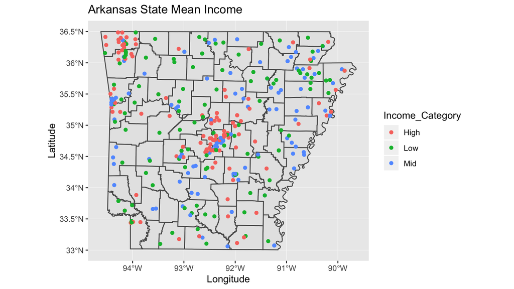

It is apparent in the map that income and population density are connected, for instance the collection of population visible in the middle is the city of Little Rock.

Knowing this, we wanted to form a better picture of what income differences look like for people living in specific areas. We wanted to look at how income is related to resource distribution in a smaller area, one with less variation in population.

# Resource Distribution in Little Rock

In the second map, we considered resources that might vary based on income, and zoomed in on Pulaski County, the home of Little Rock, to plot the differences in greater detail. We started by plotting private versus public schools, because we thought that this might tell us about what children in different areas have access to. We then plotted data for four year colleges museums, jails, city hall/courthouses, and law enforcement, hospitals, and factories.

[interactive chart not shown]

# Conclusion

Before creating our maps, we anticipated that high income neighborhoods would have greater access to resources. We anticipated some of the markers we chose would be more prevalent in high income areas while some, like jails and factories, would be more prevalent in lower income areas. After completing our maps, we found the results slightly different than we expected. We can see resources gathered at a city center in Little Rock, which was expected. These included the City Hall, museums and law enforcement, which especially make sense to be focused in the city center. We can also see a fairly even distribution of publicly provided resources like law enforcement across income categories, which also makes sense. We saw the most income based variation when looking at the placement of private schools. Private schools were mainly concentrated in areas on a higher end of the wealth bracket. This indicates wealth based segregation and students attending these schools, mainly from higher income backgrounds, are gaining access to better educational resources. It also suggests that higher income students have accesses to more choices in terms of their educational opportunities. Drawing from this project, we recommend further research into why students are going to private schools and what they are gaining from attending private schools rather than public schools. We suggest research into why higher income students choose to attend private schools and how public schools can be improved, so that lower income students do not miss out on valuable opportunities. All children should recieve equal access to quality education and should not have to on private schools, which have shown to be discriminatory, to close the gaps which our public schools cannot fill.

# Sources

http://gis.arkansas.gov/

https://www.kaggle.com/goldenoakresearch/us-household-income-stats-geo-locations

https://www.tolerance.org/magazine/spring-2004/brown-v-board-timeline-of-school-integration-in-the-us